# ggplot2 Tutorial

#### 5.3.2 범주형 변수와 모양(`shape`) 속성의 매핑

`shape` 속성은 점의 모양을 결정한다. 다음은 앞의 산점도를 구동 방식(`drv`)에 따라 점의 모양이 다르게 표시한 예이다.

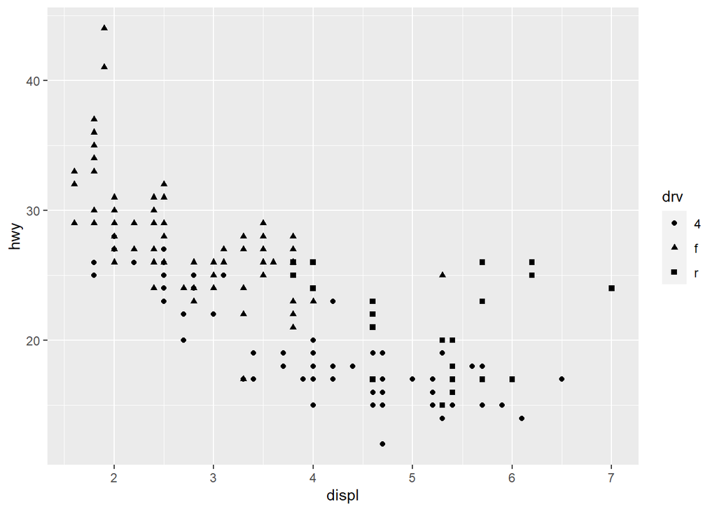

```r
ggplot(mpg, aes(x = displ, y = hwy, shape = drv)) + geom_point()
```

점의 모양과 색상을 하나의 데이터 열에 매핑하여 좀 더 데이터가 뚜렷이 구분되게 그래프를 그리기도 한다.

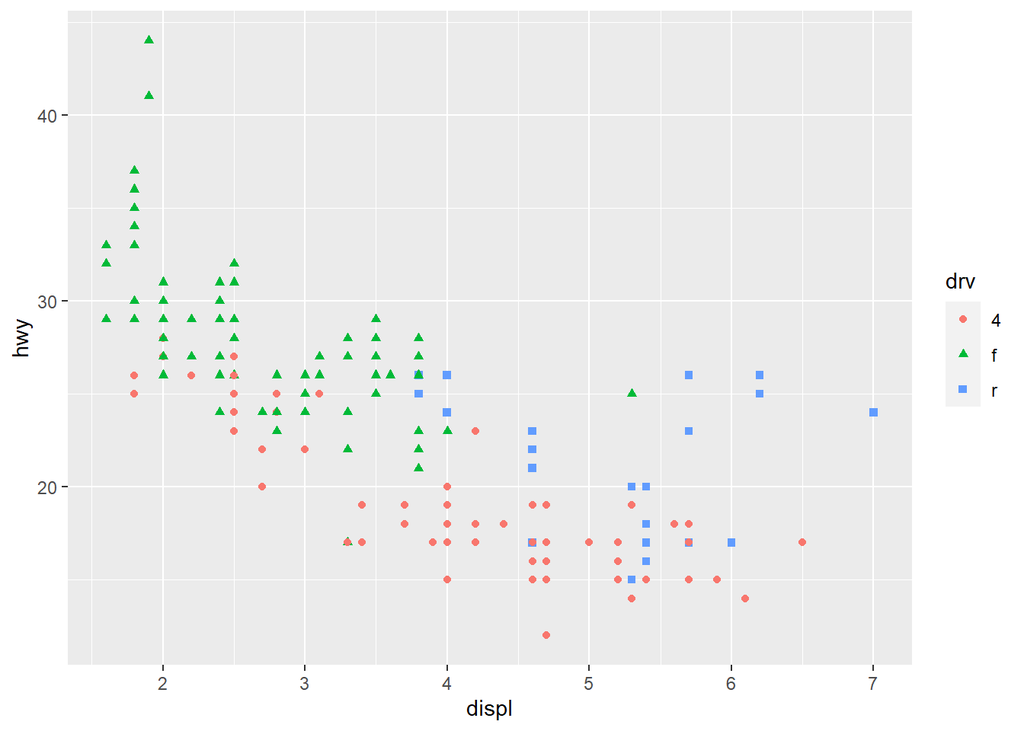

```r
ggplot(mpg, aes(x = displ, y = hwy, shape = drv, color = drv)) +
  geom_point()
```

물론 다음처럼 점의 색상과 모양을 각각 데이터의 다른 열에 매핑할 수도 있다. 다음은 점의 색은 자동차의 종류(`class`)에 모양은 자동차의 구동방식(`drv`)에 매핑한 결과이다.

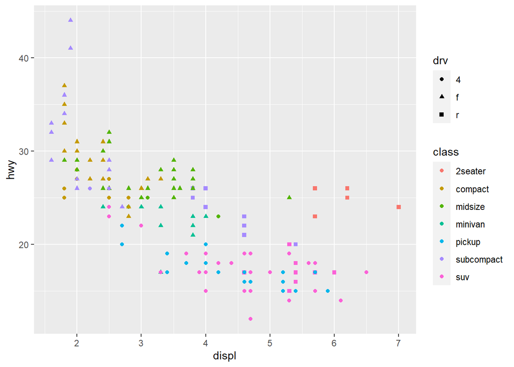

```r
ggplot(mpg, aes(x = displ, y = hwy, shape = drv, color = class)) +
  geom_point()
```

`shape`을 사용할 때 주의할 점은 shape은 최대 6개의 모양으로만 점을 구분하기 때문에 `class` 열처럼 6개보 많은 종류가 있는 열에 매핑되면 데이터가 제대로 표시가 되지 않는다. 다음 예처럼 `shape` 속성에 `class` 열을 매핑하니 경고가 나타나고 suv 데이터를 표시하지 못한 것을 확인할 수 있다.

```
#> Warning: The shape palette can deal with a maximum of 6 discrete values because
#> more than 6 becomes difficult to discriminate; you have 7. Consider
#> specifying shapes manually if you must have them.
#> Warning: Removed 62 rows containing missing values (`geom_point()`).
```

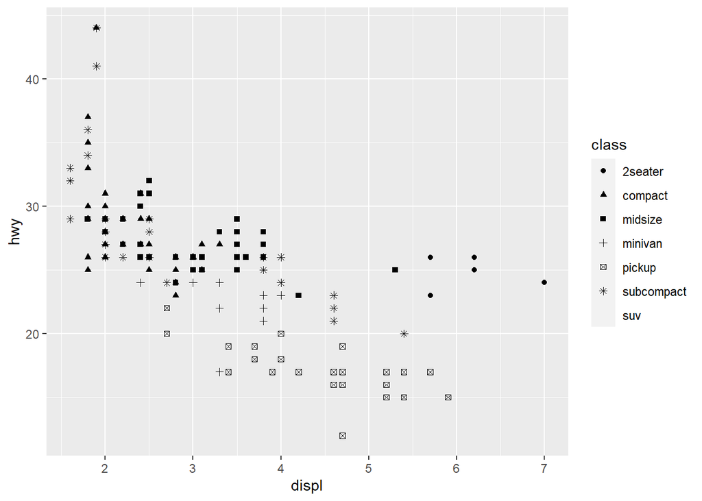

```r
ggplot(mpg, aes(x = displ, y = hwy, shape = class)) + geom_point()
```

#### 5.3.3 연속형 변수와 크기(size), 색상(color), 투명도(alpha) 속성의 매핑

모양(`shape`) 속성은 소수의 구분되는 값으로 표현되는 범주형 변수를 표현하기 좋다. 데이터의 열이 연속형 변수이면 연속적인 값을 표현하기 좋은 가로축(`x`), 세로축(`y`), 크기(`size`), 투명도(`alpha`) 등을 이용하는 것이 좋다. 색상(`color`)은 범주형 변수와 연속형 변수에 모두 매핑될 수 있다. 범주형 변수로 매핑되면 구분되는 색상으로, 연속형 변수로 매핑되면 색상의 그라데이션으로 값을 표시한다.

다음은 도심 연비와 고속도로 연비를 가로축과 세로축으로 하는 그래프에서 점의 크기 속성을 배기량 열에 매핑한 결과이다. 도심 연비와 고속도로 연비가 좋은 차들은 배기량이 작은 차임을 알 수 있다.

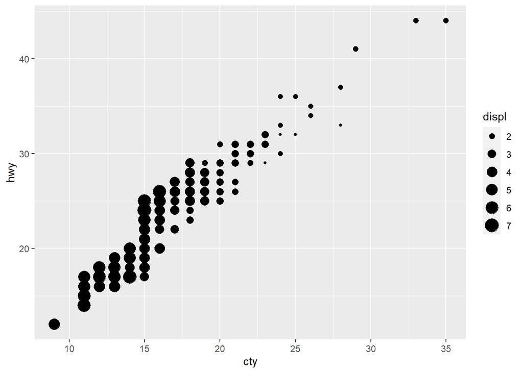

```r
ggplot(mpg, aes(x = cty, y = hwy, size = displ)) + geom_point()
```

다음은 동일한 도심 연비와 고속도로 연비 산점도에서 그래프에서 점의 색상을 배기량 열에 매핑한 결과이다. 범주형 변수가 매핑될 때와는 달리 색상의 연속적인 변화인 그라데이션을 사용하여 배기량을 표현하고 있음을 볼 수 있다.

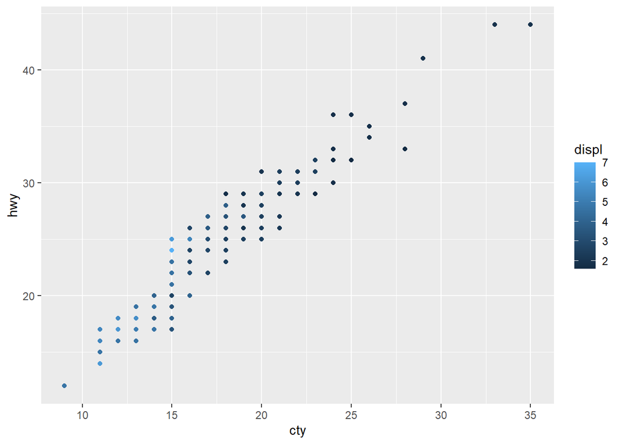

```r
ggplot(mpg, aes(x = cty, y = hwy, color = displ)) + geom_point()
```

다음은 동일한 도심 연비와 고속도로 연비 산점도에서 그래프에서 점의 투명도를 실린더 수 열에 매핑한 결과이다.

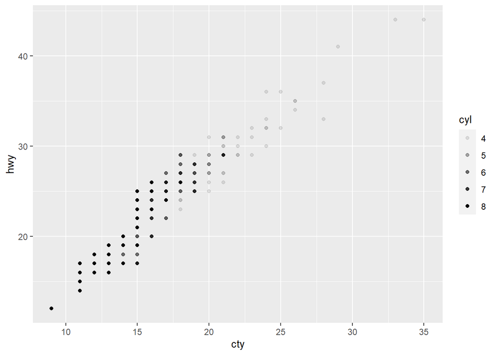

```r
ggplot(mpg, aes(x = cty, y = hwy, alpha = cyl)) + geom_point()
```

### 5.4 ggplot 명령문을 입력할 때 자주 발생하는 문제들

ggplot은 매우 강력한 기능을 가지고 있지만 Excel 등의 GUI 프로그램에만 익숙한 사람은 문자 기반 명령어를 입력하는 것에 어려움을 느낄 수 있다. 컴퓨터는 사람만큼의 유연성을 발휘하지 못하므로 컴퓨터는 자신이 실행해야 할 명령문의 문법에 매우 까다롭게 반응한다. ggplot 명령어 입력시 흔히 발생하는 문제들은 다음과 같다.

- R 명령문은 대소문자를 구분한다. 따라서 `Color`와 `color`는 ggplot에서 서로 다른 인수로 인식되어 오류가 발생한다.
- ggplot 명령문의 키워드의 철자가 틀리면 다른 키워드로 간주하기 때문에 오류가 발생할 수 있다. 이를 방지하려면 키워드의 일부만 입력한 후 `Tab` 키를 눌러 자동완성 기능을 사용하여 입력하는 것을 권장한다.
- ggplot2의 명령문을 입력할 때 여러 함수를 합쳐서 실행하기 위하여 `+` 연산자를 이용한다. ggplot2의 명령문이 길어지면 명령문을 여러 줄로 쓰는 것이 필요한데, 보통 `+`로 연결되는 곳에서 줄바꿈하는 것이 읽기에 좋다. 이 때 주의할 점이, 줄바꿈을 `+` 앞이 아니라 뒤에서 해야 한다는 것이다. `+` 앞에서 하면 R은 명령문의 입력이 완성된 것으로 간주하기 때문이다.

다음은 산점도와 추세선을 한 그래프에 그린 예이다.

```r
ggplot(mpg, aes(x = displ, y = hwy, color = drv)) + geom_point() + geom_smooth()
```

[output not shown]

```r
ggplot(mpg, aes(x = displ, y = hwy, color = drv)) +
  geom_point() +
  geom_smooth()
```

만약 다음처럼 `+` 위치가 잘못되면 오류가 발생한다. 왜 이런 결과가 나왔고 오류 메시지의 의미는 무엇일까? **R**은 **Enter**로 명령문을 구분한다. 그러므로 첫번째 줄은 `+`가 없으므로 완벽한 명령문이기 입력된 것으로 간주하고 실행이되어 좌표평면만 그린 것이다. 그러고 나서 두번째 줄을 새로운 명령문으로 실행을 한다. 그런데 갑자기 명령문이 `+`로 시작하니 **R**은 명령문에 오류가 있다고 판단한다. 왜냐하면 `+` 연산은 왼편과 오른편에 더할 요소가 있어야 하는데, 왼편의 요소가 기술되지 않았기 때문이다.

```r
ggplot(mpg, aes(x = displ, y = hwy, color = drv))
+ geom_point()
```

[output not shown]

- R 명령문이 조금 길어지면 가장 흔하게 발생하는 실수가 `( )`와 `" "`을 짝을 맞추어 제대로 입력하지 못하는 것이다. `ggplot2`의 명령문도 많은 함수를 사용하다 보니 이를 주의하여야 한다. 이러한 실수를 하게 되면면 R 콘솔은 명령이 계속 입력 중이라고 생각하여 `>`가 아니라 `+`를 콘솔의 프롬프트로 표시한다. 이 경우 가장 간단한 해결책은 `Esc` 키를 눌러 명령 입력에서 빠져나와 다시 명령문을 입력하는 것이다.

### 5.5 geom 함수와 그래프 계층

`ggplot2`의 장점은 필요에 따라 다양한 형식의 그래프를 쉽게 만들 수 있고, 만들 수 있는 형식도 무궁무진하다는데 있다. 그리고 `ggplot2` 그래프의 계층적 구조가 이러한 무궁무진한 그래프 형식을 만들어 내는 핵심 요소라 할 수 있다. `ggplot2`는 좌표평면 위에 여러 계층으로 그래프를 겹쳐 그려서 하나의 좌표평면에 나타냄으로써 복잡한 형식의 그래프를 만들어 낼 수 있다.

```r
ggplot(mpg, aes(x = displ, y = hwy, color = drv)) +
  geom_point() +
  geom_smooth()
```

[output not shown]

`ggplot()` 함수가 여러 개의 geom 함수와 연결되면, 하나의 좌표평면에 각각의 geom() 함수의 결과를 층층이 그린다. 이 때, 명령문에 나타나는 순서에 따라 첫번째 나온 geom 함수의 도형이 가장 아래 계층에, 다음에 나오는 geom 함수의 도형이 차례로 그 윗 계층에 그려진다.

#### 5.5.1 geom 함수에서 속성 매핑하기

앞의 배기량과 고속도로 연비의 산점도와 추세선을 그린 그래프에서 추세선을 선 종류(`linttype`)가 구동 방식(`drv`)에 따라 다르게 표현하고 싶다. 그런데 산점도는 점이라는 도형으로 그래프를 그리므로 선 종류라는 속성을 가지고 있지 않다. 그리고 산점도도 점의 모양(`shape`)이 구동 방식에 따라 다르게 표현하고 싶다고 하자. 마찬가지로 추세선은 선이라는 도형으로 그래프를 그리므로 점의 모양이라는 속성을 가지고 있지 않다.

이렇듯 여러 geom 함수를 연결하여 그래프를 그릴 때, 특정 geom 함수에만 해당하는 속성은 해당 geom 함수에서 속성과 데이터 열을 매핑하는 것이 좋다. geom 함수도 `ggplot()` 함수처럼 `aes()` 함수를 이용하여 그래프 속성과 데이터 열을 매핑하는데, 이 매핑이 geom 함수의 첫 번째 인수로 기술된다는 점만 다르다.

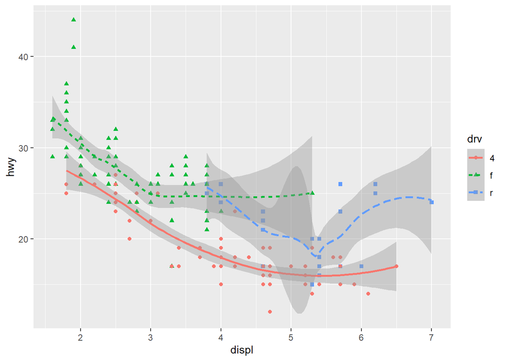

```r
ggplot(mpg, aes(x = displ, y = hwy, color = drv)) +
  geom_point(aes(shape = drv)) +
  geom_smooth(aes(linetype = drv))
```

따라서 지금까지 배운 내용으로 ggplot2 그래프를 그리는 문법을 확장하면 다음과 같다.

```r
ggplot(데이터, aes(공통속성1=열1, 공통속성2=열2, ...)) +
  geom함수1(aes(geom함수1의 속성1=열1, geom함수1의 속성2=열2, ...)) +
  geom함수2(aes(geom함수2의 속성1=열1, geom함수2의 속성2=열2, ...)) +
  ....
```

확장된 문법으로 맨처음 그린 배기량과 고속도로 연비의 산점도와 추세선 그래프에서, 산점도의 점은 구동 방식에 따라 다른 색으로 표시하지만, 추세선은 모든 데이터에 대하여 하나만 그리려면 어떻게 해야 할까? 답은 다음처럼 색상 속성을 공통 속성으로 `ggplot()`에 매핑하지 않고 산점도만의 속성 매핑이 되도록 `geom_point()`에 기술하는 것이다.

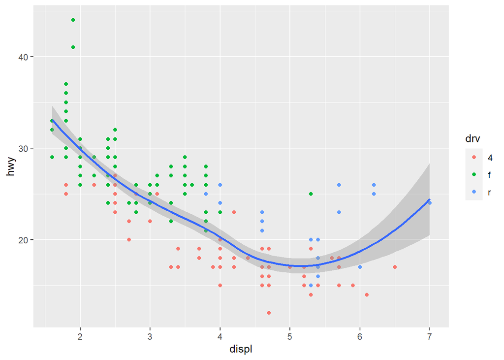

```r
ggplot(mpg, aes(x = displ, y = hwy)) +
  geom_point(aes(color = drv)) +
  geom_smooth()
```

마찬가지로 추세선을 구동 방식에 따라 다른 색상으로 표시하나 점은 모두 동일한 색으로 표시하고 싶으면 다음처럼 색상이 추세선만의 속성 매핑이 되도록 `geom_smooth()`에 기술하는 것이다.

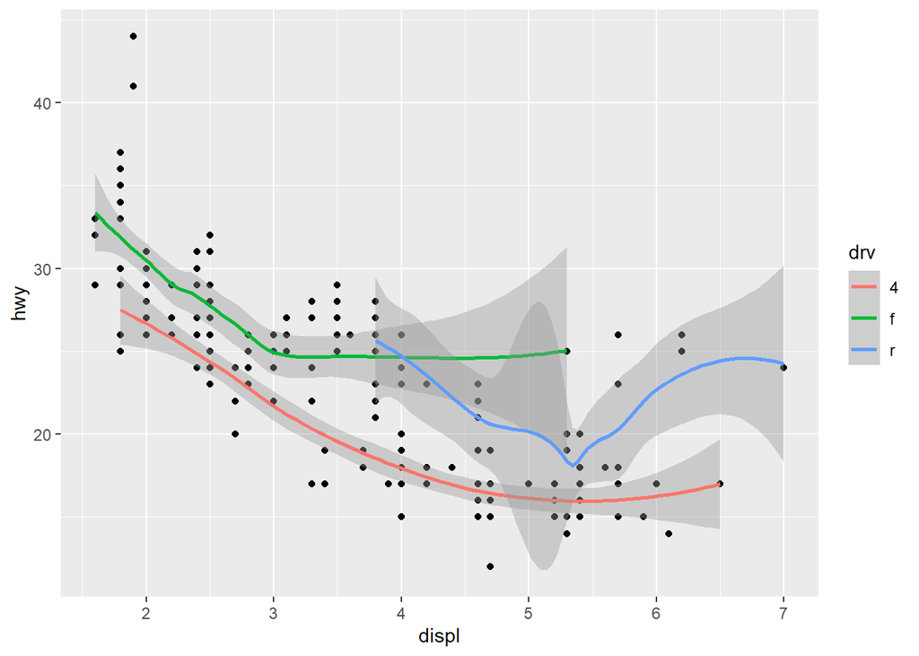

```r
ggplot(mpg, aes(x = displ, y = hwy)) +
  geom_point() +
  geom_smooth(aes(color = drv))
```

또한 `ggplot()` 함수에 데이터와 도형 속성에 대한 매핑이 되어 있어도, geom 함수에서 데이터와 도형 속성의 매핑을 재지정할 수도 있다. 이 경우 각 geom 함수에서 사용하는 `data`와 `mapping`은 다음 규칙에 의해 결정된다.

- geom 함수는 `ggplot()` 함수에 설정된 `data`와 `mapping`을 상속받아 그래프를 그린다.
- 만약 geom 함수에 `data` 인수가 설정되면 `ggplot()` 함수에 설정된 data는 무시된다.
- 만약 geom 함수에 `mapping` 인수가 설정되면 `ggplot()` 함수에 설정된 `mapping`에 geom 함수에 설정된 `mapping이` 추가된다. 만약 동일한 도형 속성에 대한 정의가 두 군데 나타나면 geom 함수의 설정이 사용된다. 자세한 내용은 R 프로그래밍의 그래프 계층(layers)과 도형(geoms) 절을 참조하기 바란다.